# Data Science Capstone: Milestone Report

Farah M

11/29/2020

## Summary

This is a milestone report for the Capstone Project of the John Hopkins University Data Science Specialization. The objective of this report is to:

1. Demonstrate that the data has been downloaded and successfully loaded.
2. Create a basic report of summary statistics about the data sets:
   - Word counts, line counts
   - Plots to illustrate features of the data
3. Report any interesting findings from the initial exploratory analysis of the data sets.
4. Briefly summarize next steps for creating the prediction algorithm and Shiny app.

## Loading packages

```r
suppressPackageStartupMessages({
    library(tidyverse)
    library(stringi)
    library(tm)
    library(ngram)
    library(wordcloud)
    library(RWeka)})
```

## Loading the data

```r
# File connections
blogfile <- "./data/final/en_US/en_US.blogs.txt"
newsfile <- "./data/final/en_US/en_US.news.txt"
twitterfile <- "./data/final/en_US/en_US.twitter.txt"

# Read in data
blogData <- readLines(blogfile, skipNul = TRUE, warn = FALSE)
newsData <- readLines(newsfile, skipNul = TRUE, warn = FALSE)
twitterData <- readLines(twitterfile, skipNul = TRUE, warn = FALSE)
```

## Summary Statistics of the Data Sets

```r
# Getting files sizes
blogSize   <- round(file.size(blogfile) / (2^20))
newsSize    <- round(file.size(newsfile) / (2^20))
twitterSize <- round(file.size(twitterfile) / (2^20))
fileSizeMB <- c(blogSize, newsSize, twitterSize)


# Number of lines in the files
numLines <- sapply(list(blogData, newsData, twitterData), length)

# Number of characters per file
numChars <- sapply(list(nchar(blogData), nchar(newsData), nchar(twitterData)), sum)

# Length of longest lines in each file
numCharsLines <- sapply(list(nchar(blogData), nchar(newsData), nchar(twitterData)), max)

# Number of words per file
numWords <- sapply(list(stri_count_words(blogData), stri_count_words(newsData), stri_count_words(twitterData)), sum)


summaryStats <- data.frame(
    File = c("Blog Data", "News Data", "Twitter Data"),
    File_Size = paste(fileSizeMB, " MB"),
    Lines = numLines,
    Characters = numChars,
    Max_Char_Lines = numCharsLines,
    Words = numWords
)

summaryStats
```

```
##           File File_Size   Lines Characters Max_Char_Lines    Words
## 1    Blog Data   200  MB  899288  206824505          40833 37546239
## 2    News Data   196  MB 1010242  203223159          11384 34762395
## 3 Twitter Data   159  MB 2360148  162096241            140 30093413
```

From the above summary, we note that the blog data file is largest file, but it has the fewest number of lines, while the Twitter data file is the smallest but has the most number of lines. This is not surprising as most Tweets are within the previous Tweet limit of 140 characters. We can also note that the blog data also contains more words than the other data.

## Exploratory Analysis

### 1. Preprocessing Data

#### (a) Sampling of Data

As the dataset is quite large, further analysis will be done using a sample of the data.

```r
sampleSize <- 0.005
set.seed(1996)
blogSample <- sample(blogData, length(blogData)*sampleSize)
newsSample <- sample(newsData, length(newsData)*sampleSize)
twitterSample <- sample(twitterData, length(twitterData)*sampleSize)
dataSample <- c(blogSample, newsSample, twitterSample)
length(dataSample)
```

```
## [1] 21347
```

Our sample dataset data file contains over 21,000 lines. Next step is to create a corpus for us to use in our analysis.

```r
# save the sample data into a text file.
writeLines(dataSample, "./data/sampleData.txt")

# clear up large variables to free up memory
rm(blogData, newsData, twitterData, blogSample, newsSample, twitterSample, dataSample)
```

#### (b) Creating a Corpus from the Sample Dataset

Cleaning process include removing: * non-ASCII character data * converting the remaining alpha characters to lower case * punctuation marks, excess white space, numeric data * removing URLs * removing stop words * removing profanity words

Profanity Words list is from Luis von Ahn’s research group at CMU (http://www.cs.cmu.edu/~biglou/resources/).

```r
# load the sample data
newCorpus <- readLines("./data/sampleData.txt")
newCorpus <- VCorpus(VectorSource(newCorpus))
newCorpus <- VCorpus(VectorSource(sapply(newCorpus, function(row) iconv(row, "latin1", "ASCII", sub=""))))

# converting to lowercase
newCorpus <- tm_map(newCorpus, content_transformer(tolower))

# removing punctuation and numeric data
newCorpus <- tm_map(newCorpus, content_transformer(removePunctuation), preserve_intra_word_dashes=TRUE)
newCorpus <- tm_map(newCorpus, removeNumbers)

## removing URLs
removeURL <- function(x) gsub("http[[:alnum:]]*", "", x)
newCorpus <- tm_map(newCorpus, content_transformer(removeURL))

# removing stop words
newCorpus <- tm_map(newCorpus, removeWords, stopwords("english"))

# removing profanity words
profanityWords <- readLines('./data/profanity_words.txt')
newCorpus <- tm_map(newCorpus,removeWords, profanityWords)

# removing excess white spaces
newCorpus <- tm_map(newCorpus, stripWhitespace)
```

#### The first 7 lines of content data from the created corpus.

```
## [1] " development community needs embrace new challenge uncovering effective ways develop ip exports maximum impact alleviation products exist can stimulated markets exist ip laws although somewhat disadvantageous developing countries available enforcement developed markets fair trade interventio…
## [1] "grannys fresh rolls biscuits actually bit love responsible many many many sunday dinners supplied poppys garden growing now know seriously amazing influence always t-day table every dinner ever made"
## [1] "close- button closure gate fold tied twine"
## [1] " really let sink "
## [1] " ran flannagans k morning finished minutes seconds"
## [1] "every step taken inside city walls old jerusalem checked aware foot may come rest one spots mary even st paul stepped wandering london contrast modernity antiquity playing movies british monarchy history mind walk grounds westminster abbey tower hill split second heightened awareness know ch…
## [1] " expected results previous studies significant negative relationship moralism attitude apartheid scales r sample analysed whole overall correlation moralism social desirability also maintained r "
```

### 2. Tokenization and Analysis of Word and N-gram Frequencies

We will tokenize the corpus to analyze the frequency of the words and n-grams in the dataset.

#### (a) Word frequency in the sample dataset.

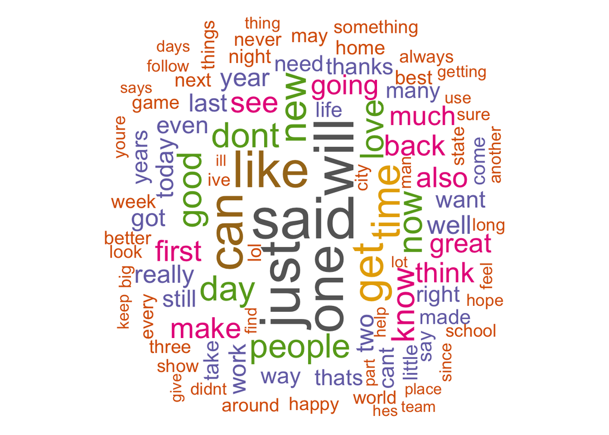

```r
# create a DocumentTermMatrix of the sample data
dtm <- DocumentTermMatrix(newCorpus)

# sort by frequency and create a dataframe of the terms and frequencies
freq <- sort(colSums(as.matrix(dtm)), decreasing = TRUE)
wordFreq <- data.frame(word = names(freq), freq = freq)


# construct word cloud
suppressWarnings (
    wordcloud(words = wordFreq$word,
              freq = wordFreq$freq,
              min.freq = 1,
              max.words = 100,
              random.order = FALSE,
              rot.per = 0.35,
              colors=brewer.pal(8, "Dark2"))
)
```

From the word cloud, we can observe that the words with the highest frequencies are: said, will, just and one.

Next, we can plot out the 20 most frequently found words.

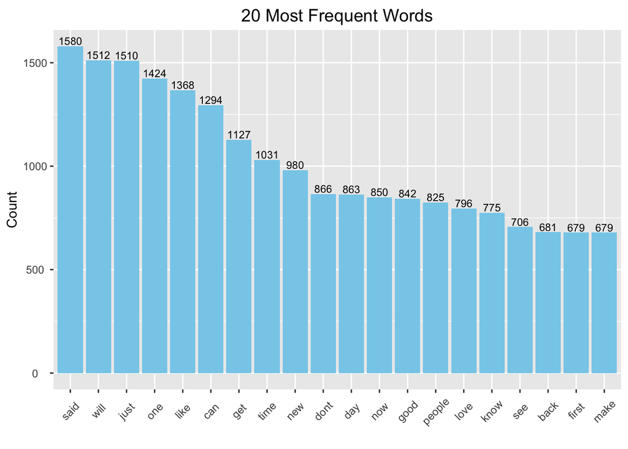

```r
# plot the top 20 most frequent words
g <- ggplot (wordFreq[1:20,], aes(x = reorder(word, -freq),
                                  y = freq))
g <- g + geom_bar(stat = "identity", fill = "skyblue")
g <- g + geom_text(aes(label = freq), vjust = -0.20, size = 3)
g <- g + xlab("")
g <- g + ylab("Count")
g <- g + theme(plot.title = element_text(size = 14, hjust = 0.5, vjust = 0.5),
               axis.text.x = element_text(hjust = 0.5, vjust = 0.5, angle = 45),
               axis.text.y = element_text(hjust = 0.5, vjust = 0.5))
g <- g + ggtitle("20 Most Frequent Words")
print(g)
```

```r
# remove variables no longer needed to free up memory
rm(dtm, freq, wordFreq, g)
```

#### (b) Frequencies of bigrams in the dataset

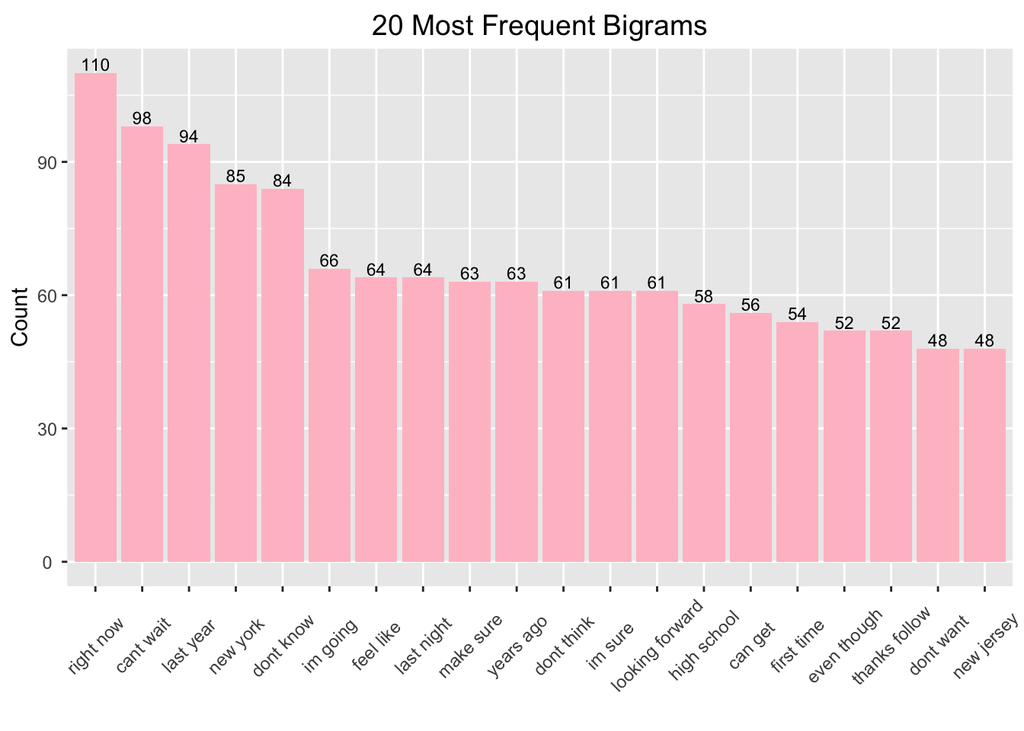

```r
# tokenizer functions to create 2-grams tokens
bigramTokenizer <- function(x) NGramTokenizer(x, Weka_control(min = 2, max = 2))

# Document term matrix for 2-grams
dtm2 <- DocumentTermMatrix(newCorpus, control = list(tokenize = bigramTokenizer))

# sort by frequency and create a dataframe of the terms and frequencies
freq2 <- sort(colSums(as.matrix(dtm2)), decreasing = TRUE)
wordFreq2 <- data.frame(word = names(freq2), freq = freq2)

# plot the top 20 most frequent bigrams
g <- ggplot (wordFreq2[1:20,], aes(x = reorder(word, -freq),
                                  y = freq))
g <- g + geom_bar(stat = "identity", fill = "pink")
g <- g + geom_text(aes(label = freq), vjust = -0.20, size = 3)
g <- g + xlab("")
g <- g + ylab("Count")
g <- g + theme(plot.title = element_text(size = 14, hjust = 0.5, vjust = 0.5),
               axis.text.x = element_text(hjust = 0.5, vjust = 0.5, angle = 45),
               axis.text.y = element_text(hjust = 0.5, vjust = 0.5))
g <- g + ggtitle("20 Most Frequent Bigrams")
print(g)
```

```r
# remove variables no longer needed to free up memory
rm(dtm2, freq2, wordFreq2, g)
```

#### (c) Frequencies of trigrams in the dataset

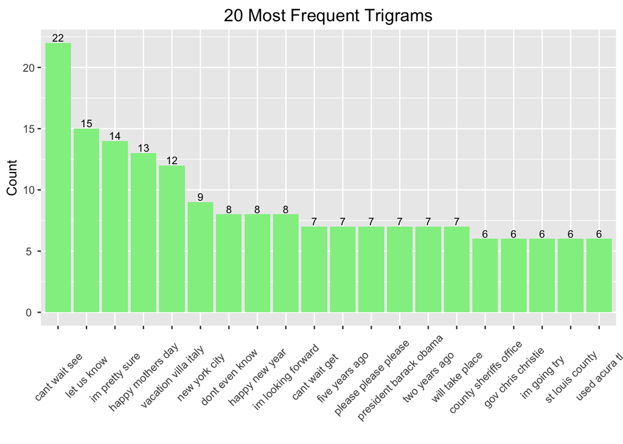

```r
# tokenizer functions to create 2-grams tokens
trigramTokenizer <- function(x) NGramTokenizer(x, Weka_control(min = 3, max = 3))

# Document term matrix for 3-grams
dtm3 <- DocumentTermMatrix(newCorpus, control = list(tokenize = trigramTokenizer))

# sort by frequency and create a dataframe of the terms and frequencies
freq3 <- sort(colSums(as.matrix(dtm3)), decreasing = TRUE)
wordFreq3 <- data.frame(word = names(freq3), freq = freq3)

# plot the top 20 most frequent trigrams
g <- ggplot (wordFreq3[1:20,], aes(x = reorder(word, -freq),
                                  y = freq))
g <- g + geom_bar(stat = "identity", fill = "lightgreen")
g <- g + geom_text(aes(label = freq), vjust = -0.20, size = 3)
g <- g + xlab("")
g <- g + ylab("Count")
g <- g + theme(plot.title = element_text(size = 14, hjust = 0.5, vjust = 0.5),
               axis.text.x = element_text(hjust = 0.5, vjust = 0.5, angle = 45),
               axis.text.y = element_text(hjust = 0.5, vjust = 0.5))
g <- g + ggtitle("20 Most Frequent Trigrams")
print(g)
```

```r
# remove variables no longer needed to free up memory
rm(dtm3, freq3, wordFreq3, g)
```

## Next Steps

The objective of the capstone project is to build a prediction model that will be deployed as a Shiny app. The user will input a word, the model will predict the next word that the user wants to type.

The predictive algorithm will be developed using an n-gram model with a word frequency lookup similar to that performed in the exploratory data analysis section of this report.

One of the issues encountered while performing this initial exploration of the dataset was the memory consumed by the objects needed for the analysis. Therefore, among the next steps, I will also be looking at ways to reduce the memory needed in order to be able to scale the data and application.